# Final Progress Report

Gujri Ahluwalia, Salah Mohammed, Esha Patel

December 11, 2022

## **Research Question**

**How have revenue streams changed for music artists, Drake and Beyonce over the last two decades?**

## **Data Used**

- **Chartmaster.org**
  - Pre Processed
  - Original data was collected from specific album and song sales, physical singles sales, digital song sales, and streaming data.
  - There was not missing data as it provided all possible breakdowns of albums and sales
  - They provide a range of data on all different types of musical artists it proves less bias.
- **Musicchartsarchive.com**
  - Pre Processed
  - Collected from the music industry record charts for all genres from 1970s-onward
  - Because this website focused only on music that has charted throughout history they are not missing anything as their focus is niche
  - The data does not prove as bias as they focus on all different genres that have charted and not specific ones
- **Billboard.come**
  - Original Data
  - The data is collected based on listeners and how often they listen or stream a specific song
  - There is no missing data as this is based on popularity of a certain song and because Billboard itself produces the Top 100
  - The data can be biased as many songs that are on the Top 100 tend to be pop/rap/r&b music rather than other genres

## **Comparing Artist that Have Most Top 10 Singles**

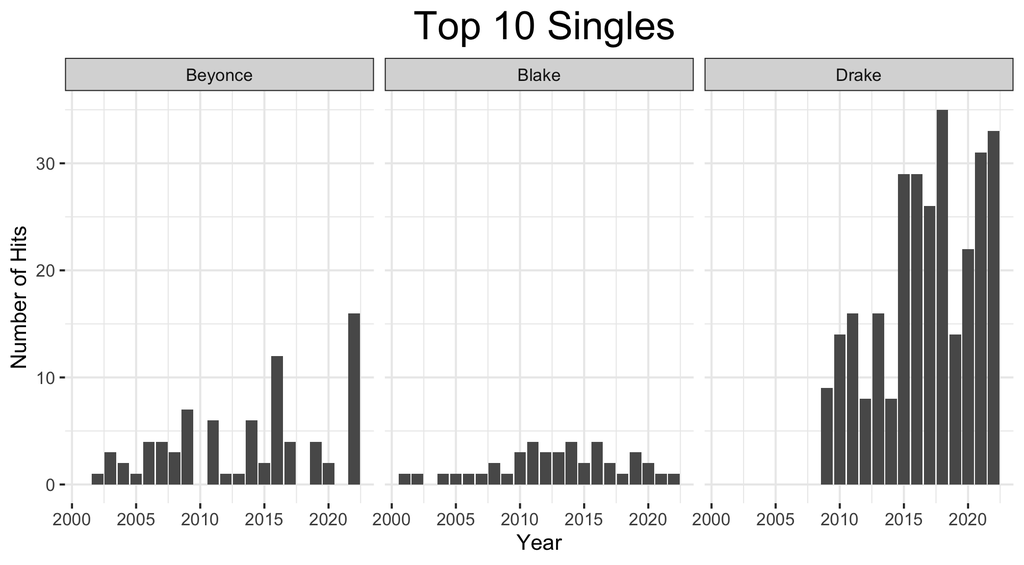

In this figure, we looked at the number of singles Beyonce, Blake Shelton, and Drake each had in the Billboard Hot 100 chart each year. Drake and Beyonce have a slight overlap in genres as Drake is a Rap and R&B artist, and Beyonce is a Pop and R&B artist. Both artists make music within the scope of Hip-Hop. Because of this, we chose to look at a third artist - Blake Shelton - who makes music in a genre of a different nature to see if the trends are consistent across music genres. What the graphs showed us is that both Drake and Beyonce’s charting numbers follow a similar upwards trend. The difference is that Drake has charted significantly more than Beyonce, having no less than 5 singles in the Billboard chart each year. Blake Shelton’s numbers on the other hand, are more consistent than the other two artists. This goes to show that trends may differ across music genres based on fan base demographic, popularity, and resources used.

## **Analysis of Largest Revenue Stream for Artist**

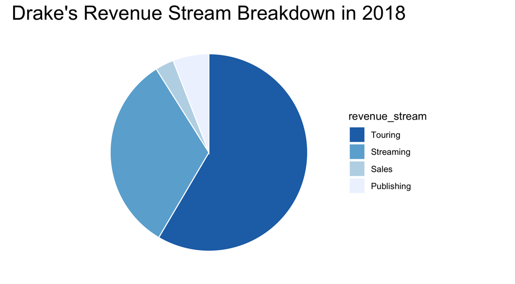

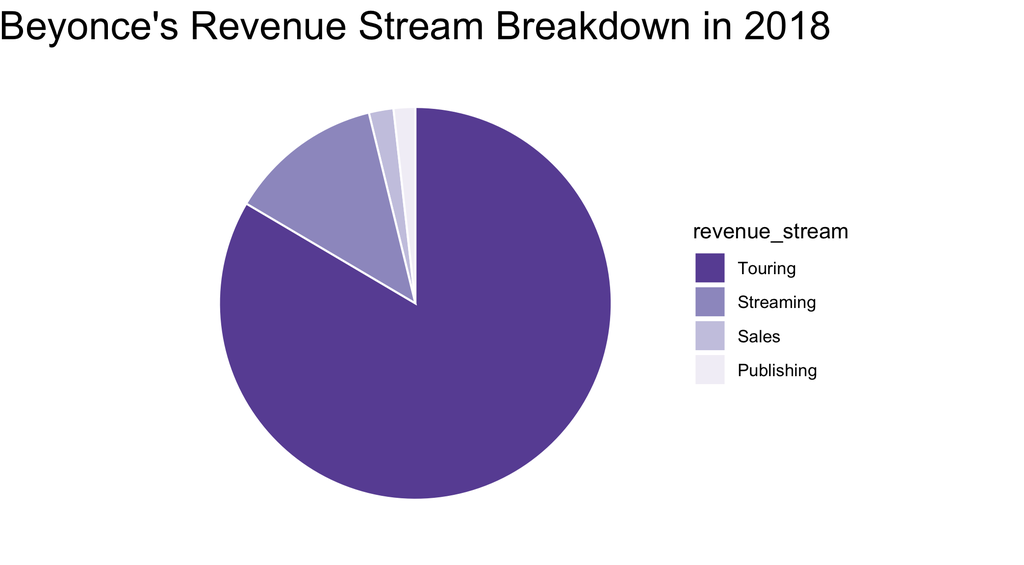

In the pie charts we created, we are looking at the breakdown of revenue streams for each artist. The data we gathered looks at each artist’s revenue as a total of touring, streaming, sales, and publishing rights. Drake’s total revenue in 2018 was $52.20 million, and Beyonce’s total was $33.10 million. One relationship is that touring makes up more than half of their revenue streams, while streaming makes up the next most significant stream. The goal was to see how many streams contribute to an artist’s total revenue stream and find a correlation with how many hits they have had throughout their careers. We found that Drake’s music streams make up about 33%, while Beyonce’s music streams make up only about 13%.

## **Amount of Time Each Artist’s Singles Charted Per Year**

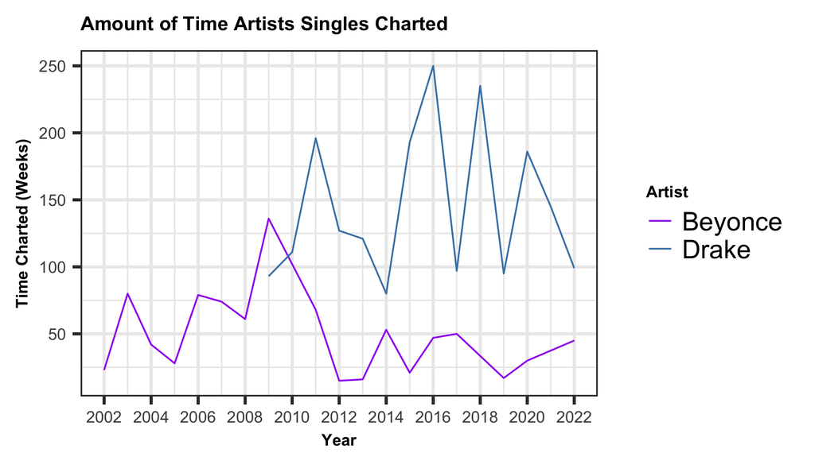

The graph compares the amount of time each artist’s singles were on the Billboard Hot 100’s Chart per year. Line graphs easily depict small changes over time, so we are clearly able to see an artist’s popularity over time. Even though they release a different number of songs each year, it does not affect how much people listen to each song. Drake has mostly charted longer than Beyonce every year with the exception of the beginning of his career. This concludes that Drake’s music is proven to be more popular than Beyonce’s each year. More people have listened to all of his songs released that year than Beyonce’s, so he has charted longer each year. His lowest yearly performance in 2014 is still higher than Beyonce’s. Because Beyonce has been around much longer, she has charted earlier than Drake. She clearly used to spend more total weeks on the Top 100’s before Drake came along in 2009. This explains that her peak was before Drake’s time. Revenue streams have definitely changed in the second decade of Beyonce’s career. She has been streamed and charted the most in the beginning of her career, so her revenue was the greatest then. However, her revenue seems to have been more steady than Drake’s. Drake, on the other hand, had a rapid growing career, but he has also had major downfalls. His revenue streams must have differed a lot by year. For example, his greatest peak in 2016 of most time charted was followed by a big downfall in 2017. Overall, both artists have been successful charting on Billboard Hot 100’s each year, but their individual patterns have been quite different.

## **Artist’s Streams Over Time**

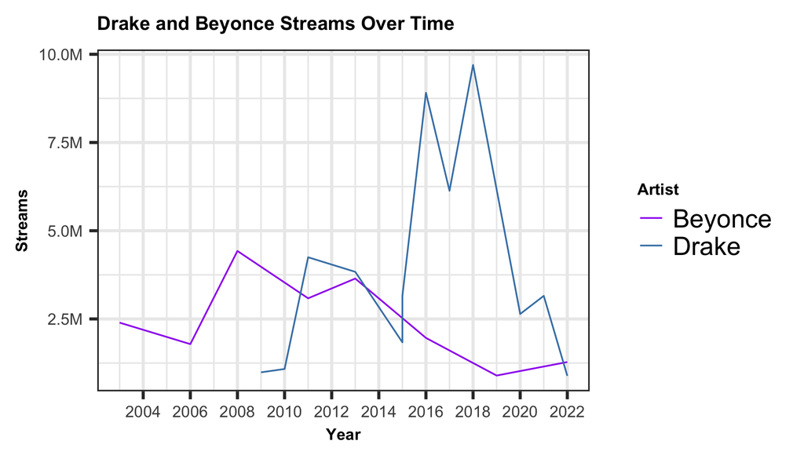

This line graph depicts audience streams of each artist’s albums per year. Drake had two time periods where people were heavily listening to his music. These are from 2010 to 2013 and from 2016 to 2018. Three of Drake’s biggest albums were released from 2010 to 2013: *Thank Me Later*, *Take Care* and *Nothing Was The Same*. The same goes from 2016 to 2018 when *Views* and *Scorpion* were released. For Beyonce, she had the most streams in 2008 and second-most in 2013. 2008 was her album *I am Sasha Fierce* and 2013 was *Beyonce*. *I am Sasha Fierce* was a catchy album with a few great ballads. Beyonce composed sounds she had never used in her music before, so it was revolutionary. Both of these albums were pivotal moments in her career. Therefore, it makes sense that both of these artists had the most streams during these years. It is interesting to note that at Drake’s peak, Beyonce’s music decreases in popularity. This could have to do with audience favoring Drake’s rap over Beyonce’s pop music. The years artists do better are when their released albums for that year proved to be more popular, since people were streaming them a lot more. This means they made their greatest revenue in these years, creating the wealth and power that they have today. Both artists have had different “hit” years that have led to their success today.

## **Artist’s Comparative Revenue Streams**

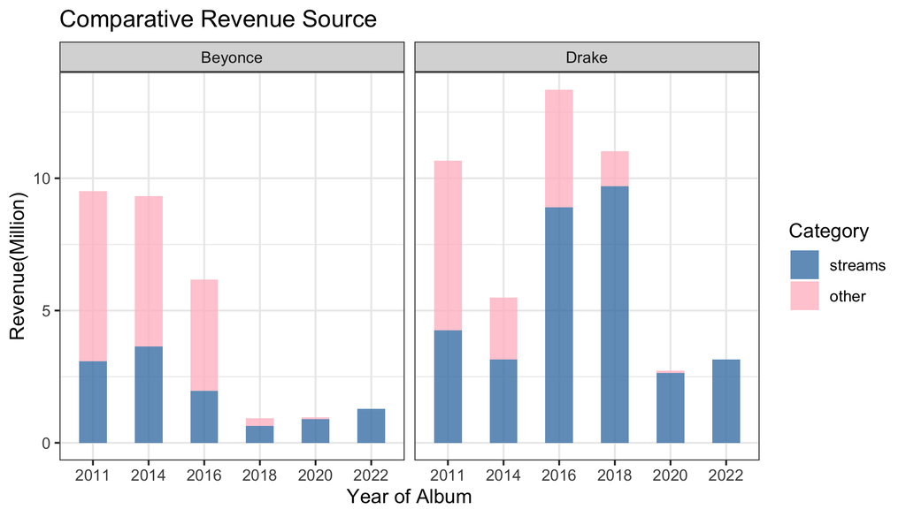

## **Frequency of Artist’s in Top 20’s Position**

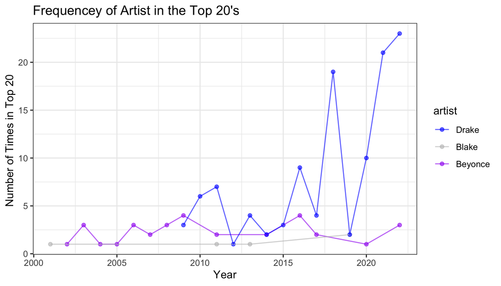

In this graph, we choose to examine how often musicians, Drake, Beyonce, and Blake Shelton, have been in the top 20 Billboard charts. The three artists all have different backgrounds: Drake has a rap and hip hop background, Beyonce has a R&B/Pop background, and Blake Shelton is a popular country singer. We choose to explore Blake Shelton along with Beyonce and Drake as he is an artist of a completely different background, fan base, and genre. While Blake Shelton has been making music longer than Beyonce and Drake, he is not as popular or mainstream. This is seen in the graph as he consistently has charted significantly less than Drake. Compared to Beyonce, he is relatively comparable; however, still has been in the top 20 less times than her. Drake has consistently made it in the top 20 a multitude of times with different drops as those were years he had not released much music during that specific time. This contributes to the artists’ revenue streams as they receive a portion of revenue made from their songs playing on any platform that plays the Billboard charted music. The graph shows that once again Drake proves to be the most popular and successful artist compared to others.

## **Appendix**

| Variable | Definition |
| --- | --- |
| Album | Album Name |
| Artist | Singer |
| Auto Update Streams | Most current sales of streams automatically updated |
| Category | Type of revenue |
| Daily Increase Streams | Sales of streams portrayed by an average and last day daily increase |
| Digital Singles | Sales of digital singles from the album |
| Last Verified Strams | Sales of streams based on when they were last verified |
| Other LPs | Sales of LPs |
| Physical Singles | Sales of physical singles from the album |
| Position | The number of the song on the Top 100’s chart |
| Revenue | Money made from total streams |
| Singles | Drake or Beyonce’s singles |
| Streams | The act of listening to a song |
| Studio Albums | Sales of original album |
| Total | Total sales through all streaming methods |
| Weeks Charted | The number of weeks on the Top 100’s chart |
| Year | The time period (year) that the music was released |